# Homework 4

**Exercise 1 (Deterministic colouring)** Let $\Pi$ a Poisson point process on $[0, \infty)$. Suppose we colour the first arrival blue, and then next arrival red, and continue colouring the points in this alternating fashion. Consider the point processes $\Gamma$ formed by considering only the blue points. Is this a Poisson point process? Explain.

*Solution.* *No*. The interarrival times between two blue points is given by the sum of *two* exponential random variables, and is no longer an exponential.

**Exercise 2 (Shop keeper)** Suppose we model the number of customers that arrive at a high street shop on at particular day by a Poisson process of intensity $\lambda >0$, where $\lambda$ is measured in customers per hour. We wish to estimate $\lambda$. Suppose the shop is really high-end and on some days has no customers, on its $6$ hours of operations. The shop keeper only keeps track of whether she had has any customers are not; that is, her records $x = (x_1, \ldots, x_n)$ are a binary sequence. Find a consisent estimtor for $\lambda$

*Solution.* Let $X_i$ be the binary Bernoulli random variables that corresponds to whether a customer arrived on the $i$th day. Note that $\mathbb{P}(X_i = 0) = e^{-6\lambda}$ and $\mathbb{P}(X_i = 1) = 1 - e^{-6\lambda}$. Assume that these are independent random variables, the law of large numbers gives that
$$n^{-1}(X_1 + \cdots X_n) \to \mathbb{E}X_1 = 1 - e^{-6\lambda},$$
as $n \to \infty$. Thus setting
$$T_n := -\frac{1}{6}\log( 1- n^{-1}(X_1 + \cdots+ X_n)),$$
we also know that $T_n \to \lambda$, as $n \to \infty$, since $\log$ is continuous.

**Exercise 3** Suppose we $\Pi$ is a Poisson point process on $[0, \infty)$ of intensity $\lambda$. Using the construction of $\Pi$ as exponential inter-arrival times, prove that conditioned on the event that the unit interval contains exactly one point, the distribution of the its location is uniform.

*Solution.* Let $X_1$ and $X_2$ be independent exponential random variables of rate $\lambda$ representing the inter-arrival times. Let $U$ be the location of the point in question. We are asked to compute
$$\mathbb{P}(U \leq x | X_1 < 1, X_2+X_1 >1)=\mathbb{P}(X_1 \leq x | X_1 < 1, X_2+X_1 >1)$$
for $0 < x <1$.
Since $X_1$ and $X_2$ are independent, we have
$$\begin{eqnarray*}
\mathbb{P}(X_1 < x, X_2+X_1 >1) &=& \int_0 ^x \lambda e^{- \lambda x_1} \Big( \int_{1-x_1} ^{\infty} \lambda e^{ -\lambda x_2} dx_2 \Big)dx_1 \\
&=&\int_0 ^x \lambda e^{-\lambda x_1} e^{-\lambda(1-x_1)}dx_1 \\
&=& x \lambda e^{-\lambda}.
\end{eqnarray*}$$
Hence, using this formula in the numerator, and also in the denominator with $x=1$, we have
$$\mathbb{P}(U \leq x | X_1 < 1, X_2+X_1 >1) = \frac{x \lambda e^{-\lambda}}{ \lambda e^{-\lambda}} =x$$
as desired.

**Exercise 4 (Random deletion)** Simulate a Poisson process of intensity $\lambda=2$, say with $10000$ arrivals. Delete each arrival independently with probability $p=\tfrac{1}{2}$ to from a new *thinned* process. Plot a histogram of the inter-arrival times of the thinned process. What should you see? Why?

*Solution.* The histogram approximates the exponential density with rate $1$, since we know that the resulting thinned process is still a Poisson process with intensity $p \lambda=1$.

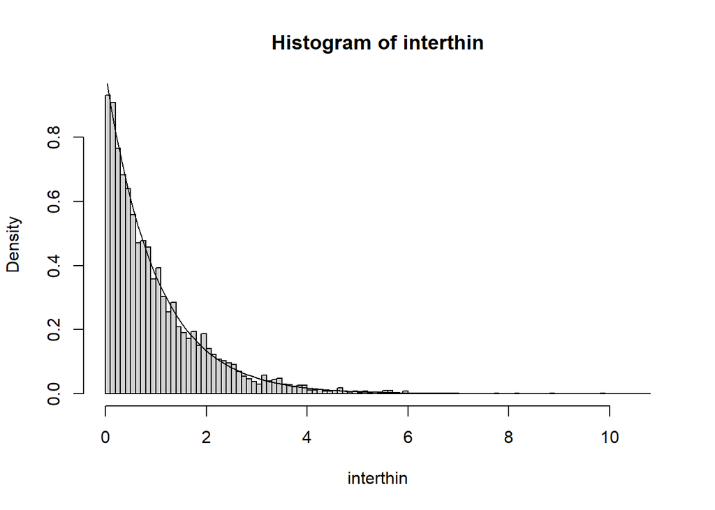

```r
inter=rexp(10000, 2)
arr = cumsum(inter)
coin = rbinom(length(arr), 1, 0.5)
for (i in 1:length(arr)) if (coin[i]==0){arr[i]<- 0}
arr<-setdiff(arr, 0)
interthin = arr[1]
for (i in 1: length(arr)-1){interthin <- c(interthin, arr[i+1] - arr[i]) }
x = seq(0, max(interthin)+1, by=0.1)
hist(interthin, prob=T, x)
curve(dexp(x), add=T)
```

**Exercise 5 (Poisson on a disc)** Simulate a Poisson point process of intensity $100$ on a disc.

*Solution.* We simulate a single point on the disc, by simulating a uniform point on a square, and keep it if lands inside an inscribed disc, or repeat otherwise. Then we implent the characterization of Poisson point processes as a Poisson number of uniform points. Note a disc has area $\pi r^2$.

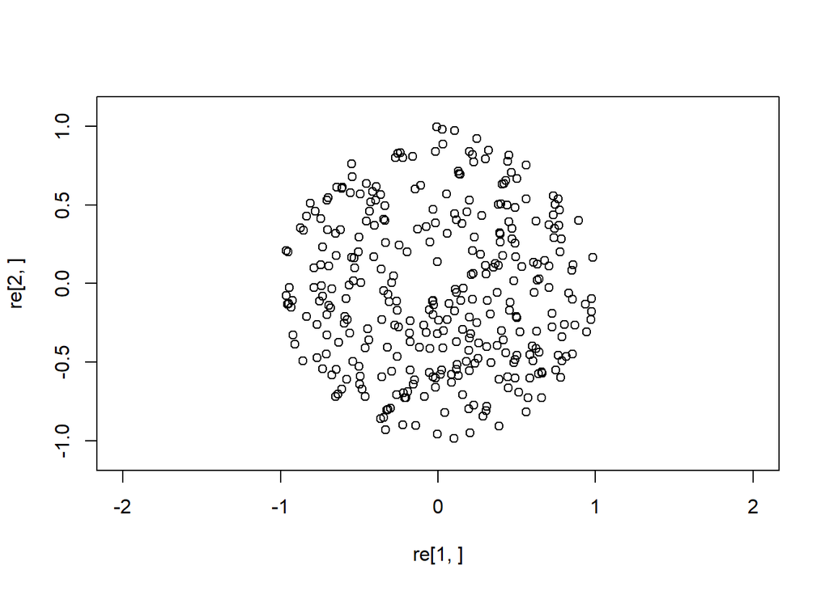

```r
point <- function(){
  z=2
  while(length(z)==1){
  x = 2*runif(1) -1
  y = 2*runif(1) -1
if (x^2 + y^2 <1) { z<-c(x,y)}
  }
  z
}
 re=replicate(rpois(1,100*pi), point())
 plot(re[1,], re[2,], xlim=c(-1.1,1.1), ylim=c(-1.1,1.1), asp=1)
```

- Version: 02 November 2020
- [Rmd Source](https://tsoo-math.github.io/ucl/QHW4-sol.Rmd)